# Assignment-2

TemmirlanZholaman

2023-02-13

```
##    ID Carrier FlightNo Destination DepartTime Day Month FlightLength Delayed30
## 1   1      UA      403         DEN      4-8am Fri   May          281        No
## 2   2      UA      405         DEN     8-Noon Fri   May          277       Yes
## 3   3      UA      409         DEN      4-8pm Fri   May          279        No
## 4   4      UA      511         ORD     8-Noon Fri   May          158        No
## 5   5      UA      667         ORD      4-8am Fri   May          143        No
## 6   6      UA      669         ORD      4-8am Fri   May          150        No
## 7   7      UA      673         ORD     8-Noon Fri   May          158        No
## 8   8      UA      677         ORD     8-Noon Fri   May          160        No
## 9   9      UA      679         ORD   Noon-4pm Fri   May          160        No
## 10 10      UA      681         ORD   Noon-4pm Fri   May          163       Yes
```

## Exploratory Data Analysis

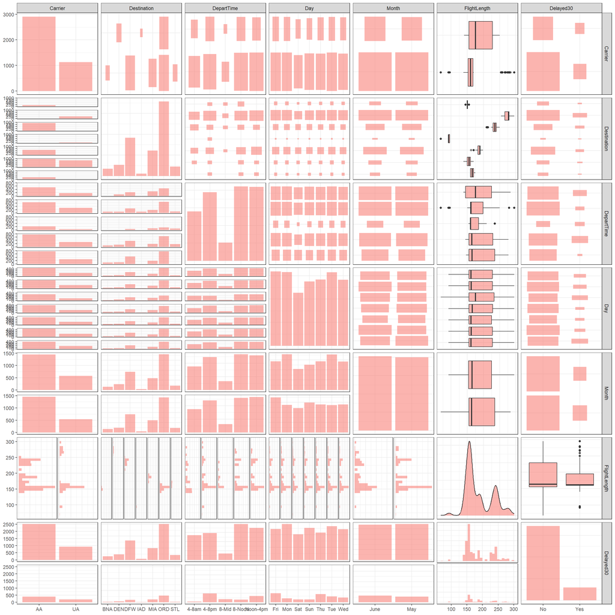

### After looking for the data, I am interested in checking: So basically, most of my hypothesis will be constructed on flight duration versus all of the factors, due to my personal interest. The list of questions I will try to answer with data are the following:

- Is there a difference for delayed and non delayed flights in their Flight Length? (may be delayed flights are longer, or there is a tendency to delay a longer flights)
- Do different Carriers have difference in Flight Duration
- Can we say, that some of the Carriers tend to Delay more often, than others? (Proportion question)
- Can we say, that the delay proportion varies with dates?
- Is there a tendency that flights being delayed on different departure times differently?

### Question 1: Can we say, that Delayed Flights and Non-Delayed Flights have different Flight Length (or flights that being delayed have different flight length)

```r
Delayed_FlightLen <- (data%>%filter(Delayed30=="Yes"))$FlightLength
NotDelayed_FlightLen <- (data%>%filter(Delayed30=="No"))$FlightLength
hyp1<-t.test(Delayed_FlightLen, NotDelayed_FlightLen)
hyp1
```

```
##
##  Welch Two Sample t-test
##
## data:  Delayed_FlightLen and NotDelayed_FlightLen
## t = -1.5092, df = 841.27, p-value = 0.1316
## alternative hypothesis: true difference in means is not equal to 0
## 95 percent confidence interval:
##  -6.2146789  0.8119983
## sample estimates:
## mean of x mean of y
##  183.0000  185.7013
```

###### Conclusion:

When testing the null hypothesis, that $\mu_1 - \mu_2 = 0$, we cannot reject the null hypothesis, as the p-value is 0.1316357. The result is statistically insignificant, the null cannot be rejected

### Question 2: Is there a difference in mean FlightLen between Carriers?

```r
AA_FlightLen <- (data%>%filter(Carrier=="AA"))$FlightLength
UA_FlightLen <- (data%>%filter(Carrier=="UA"))$FlightLength
hyp2<-t.test(AA_FlightLen, UA_FlightLen)
hyp2
```

```
##
##  Welch Two Sample t-test
##
## data:  AA_FlightLen and UA_FlightLen
## t = 3.1955, df = 1530.2, p-value = 0.001424
## alternative hypothesis: true difference in means is not equal to 0
## 95 percent confidence interval:
##  2.141152 8.948157
## sample estimates:
## mean of x mean of y
##  186.8465  181.3019
```

###### Conclusion

From this simple t-test with independent samples we see, that there is a difference between flight length between airlines, equal to 5.5446544 with 95% CI of [2.1411522, 8.9481567], p-value is 0.0014243

### Question 3: Is there enough evidence suggesting, that the proportions of delayed flights is not the same for different Carriers?

```r
num_flights_aa <- as.numeric(count(data%>%filter(Carrier=="AA")))
num_flights_ua <- as.numeric(count(data%>%filter(Carrier=="UA")))

num_del_flights_aa<- as.numeric(count(data%>%filter(Carrier=="AA",
                                        Delayed30=="Yes")))
num_del_flights_ua<- as.numeric(count(data%>%filter(Carrier=="UA",
                                        Delayed30=="Yes")))
hyp3<-prop.test(x=c(num_del_flights_aa, num_del_flights_ua),
          n=c(num_flights_aa, num_flights_ua))
hyp3
```

```
##
##  2-sample test for equality of proportions with continuity correction
##
## data:  c(num_del_flights_aa, num_del_flights_ua) out of c(num_flights_aa, num_flights_ua)
## X-squared = 13.462, df = 1, p-value = 0.0002434
## alternative hypothesis: two.sided
## 95 percent confidence interval:
##  -0.07278702 -0.02005066
## sample estimates:
##    prop 1    prop 2
## 0.1352374 0.1816563
```

###### Conclusion

We reject the null as the result is significant with p-value =2.4343736^{-4},X-sq = 13.4620521, and 95 CI estimates are [-0.072787, -0.0200507]

### Question 4: Is there a tendency, that flights are being delayed on different days with different proportions?

```r
days_count = rep(0, length(unique(data$Day)))
days_delayed = rep(0, length(unique(data$Day)))
idx=1
for (day in unique(data$Day)){
  days_count[idx]<-as.numeric(count(data%>%filter(Day==day)))
  days_delayed[idx]<-as.numeric(count(data%>%filter(Day==day,
                                                    Delayed30=="Yes")))
  idx <- idx + 1
  }
hyp4<-prop.test(x=days_delayed,
          n=days_count)
names(hyp4$estimate)<- to_list(for(day in unique(data$Day))day)
hyp4
```

```
##
##  7-sample test for equality of proportions without continuity
##  correction
##
## data:  days_delayed out of days_count
## X-squared = 104.47, df = 6, p-value < 2.2e-16
## alternative hypothesis: two.sided
## sample estimates:
##        Fri        Sat        Sun        Mon        Tue        Wed        Thu
## 0.22605965 0.10375276 0.07985481 0.09682540 0.14808917 0.13475177 0.23321555
```

###### Conclusion

We reject the null as the result is significant with p-value =2.9281178^{-20},X-sq = 104.46788

### Question 5: Is there a tendency that flights being delayed on different departure times differently?

```r
dep_time_count = rep(0, length(unique(data$DepartTime)))
days_delayed = rep(0, length(unique(data$DepartTime)))
idx=1
for (DepTime in unique(data$DepartTime)){
  dep_time_count[idx]<-as.numeric(count(filter(data,DepartTime==DepTime)))
  days_delayed[idx]<-as.numeric(count(data%>%filter(DepartTime==DepTime,
                                                    Delayed30=="Yes")))
  idx <- idx + 1
}
hyp5<-prop.test(x=days_delayed,
          n=dep_time_count)
names(hyp5$estimate)<- to_list(for(DepTime in unique(data$DepartTime))DepTime)
hyp5
```

```
##
##  5-sample test for equality of proportions without continuity
##  correction
##
## data:  days_delayed out of dep_time_count
## X-squared = 271.98, df = 4, p-value < 2.2e-16
## alternative hypothesis: two.sided
## sample estimates:
##      4-8am     8-Noon      4-8pm   Noon-4pm      8-Mid
## 0.03147353 0.07122507 0.24794239 0.16603053 0.33073930
```

###### Conclusion

We reject the null that proportion of the delayed flights is the same in different department times. It seems, that most of the flights are delayed in the second part of the day, especially in 4-8pm and 8-midnight. p-val is 1.1919235^{-57} and X-squared is 271.9834045

# Summary

In this dataset we can see interesting patterns: * We do not have evidence, that delayed and non delayed flights have different average flight length * AA flight carriers has 5.54 units higher flight duration on average, than UA flight carriers * Also, AA flight carriers tend to delay flights less frequently than UA carriers * Finally, there is enough evidence, to state that on different days, delay proportions are different. Especially, on Friday and Thursday they are the highest